# Instruction

**InnovaTest** is an open-source 4PL curve fitting software.

### Four Parameter Logistic (4PL) Regression

It is quite useful for dose response and receptor-ligand (i.e. ELISA) assays, or other similar types of assays. To fit the curve, following values are need to be known:  
`y` - system signal (i.e. optical density)  
`x` - calibration factor (concentration)  
**Parameters**:  
`A` - the minimum value that can be obtained (signal at 0 dose)  
`B` - slope of the curve (related to the steepness of the curve at point C)  
`C` - the point of inflection (point of curve halfway between A and D)  
`D` - the maximum value that can be obtained (signal at infinite dose, plateau)  
The model makes S-shaped curve, called *logistic sigmoid*. The equation is:

`(1)`
$$y = D + \frac{A - D}{1 + \Big(\cfrac{x}{C}\Big)^B}$$

#### Example of 4PL curve

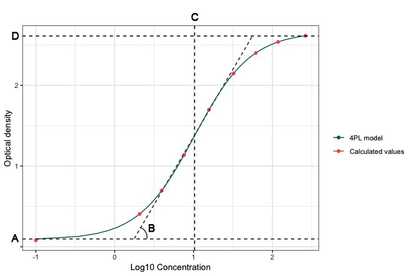

This software use R package `drc` (Ritz *et al.*, 2015) to fit the model from raw data. It calculates coefficients (`A`,`B`,`C`,`D`) based on equation `(1)` and solves equation `(2)` using them.

### Table mode

Table mode is easier to use if you are not familiar with essays such ELISA and dose response analysis.  
To use table mode `.csv` of `.xls` table should be created. First column is Concentration, fill the it with values indicationg the concentration of defined calibrators. Next columns should be filled with response values (optical density). Each cell is set for one replicate, so if you have three replicates of one sample in your experiment, than 3 cells in row should be filled.

##### Structure of table

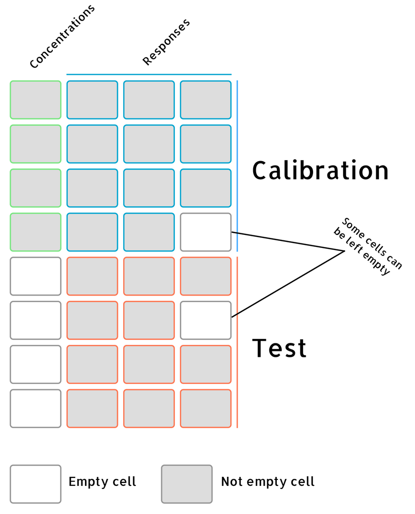

#### Options

**Maximum number of replicates** - specify maximum number of replicates in your experiment. If all samples have 2 replicates and one has 3, then select 3.  
**Choose file type** - choose format of your input file. If it is a `csv`, then `\tab` is considered as column separator and `dot` is a decimal separator **Output file name** - is set as a current date by default, but you can change it.

### Plate mode

This mode is convenient if you are familiar with ELISA essays, so using it, you are able to use raw plate data straight from your spectrophotometer with scheme of plate, which defines positions of calibratiors and test samples in your plate.

#### Options

**Input file** - in plate mode the only supported format is `xls`  
**Concentrations** - paste list of calibrators’ concentrations with commas in-between (without spaces or any other symbols)

To process the whole plate you need to make a scheme of plate right below your data in excel spreadsheet.  
`C` - Calibrators `T` - Tests

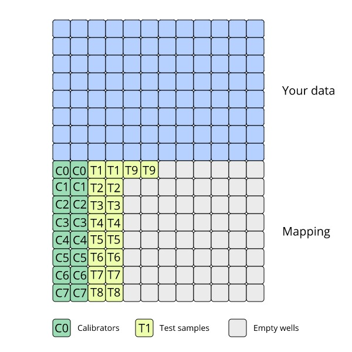

### Results

Results are shown in a convenient format after the `Calculate` button is pushed. It contains table with calculated concentrations’ values, mean ODs, variation coefficient and 4PL curve generated based on resulting table

### Troubleshooting

1. When using table mode and `csv` input file make sure that all columns have proper names displayed (Concentration, OD1, OD2…). In case there are NAs in column names, tune `Maximal number of replicates` parameter;
2. There should be no column headers in your input file;
3. Pay attention to decimal separator and column separator in csv files (decimal - `dot`, between-column - `\tab`).

P.S. in case you have any questions and ideas, feel free to contact:  
poleshchukolala@gmail.com  
https://github.com/polololya

### Links

1. Ritz, C., Baty, F., Streibig, J. C., Gerhard, D. (2015) Dose-Response Analysis Using R PLOS ONE, 10(12), e0146021

### Licence

InnovaTest. Web-based software to process data from ELISA and calculate ED50/LD50/IC50  
based on 4PL sigmoid curve. Copyright (c) 2018 Olga Poleshchuk, Ruslan Al-Shehadat

This program is free software: you can redistribute it and/or modify  
it under the terms of the GNU General Public License as published by  
the Free Software Foundation version 3 of the License, or  
any later version.

This program is distributed in the hope that it will be useful,  
but WITHOUT ANY WARRANTY; without even the implied warranty of  
MERCHANTABILITY or FITNESS FOR A PARTICULAR PURPOSE. See the  
GNU General Public License for more details.

You should have received a copy of the GNU General Public License  
along with this program. If not, see http://www.gnu.org/licenses/.